# Estimation Exercises

January 2020

## Exercise 1 (optional)

This exercise is for those wishing to understand stratified estimation a bit better. It is to be calculated by hand (or using R, a spreadsheet or a calculator). Note: You might have to round up or down. Consider this (very small) population:

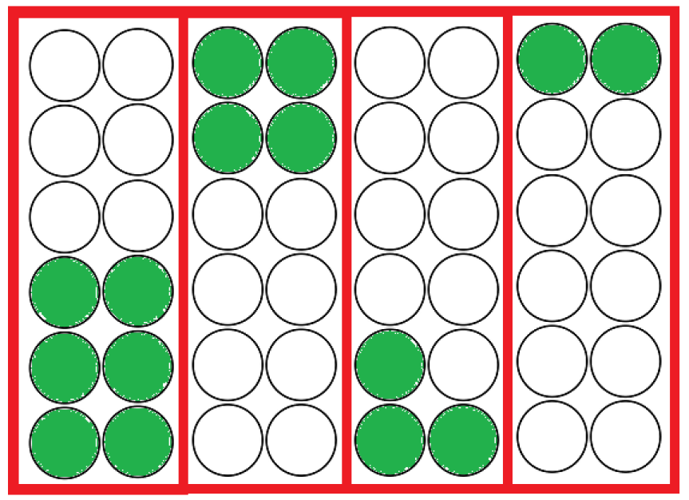

Each stratum has 12 units, i.e. \(N = 48, N_1 = N_2 = N_3 = N_4 = 12\)

And we have that:

\(n_1 = 6\), \(n_2 = 4\), \(n_3 = 3\), \(n_2 = 2\),

The units drawn satisfy (for ease of computation):

\(y_1 = y_{1_1} =y_{1_2} = y_{1_3} = y_{1_4} = y_{1_5}=y_{1_6} = 4\), \(y_2 = y_{2_1} =y_{2_2} = y_{2_3} = y_{2_4} = 6\),  
\(y_3 = y_{3_1} =y_{3_2} = y_{3_3} = 8\),  
\(y_4 = y_{4_1} =y_{4_2} = 12\).

Calculate an estimate of the population total \(\hat{t}_y = \sum_{i = 1}^4 \sum_{j=1}^{n_i} d_i y_{i_j}\)

## Exercise 2

Use the dataset **mydata_estimation**.

Given your proportional sample from last session, calculate a direct and a calibrated estimate of the number of emnployees in 2020. Use Nr_empl_reg for calibration.

Dont’r forget to check your \(g_i\)’s.

What is the ratio of the standard error of the proportional estimator to the standard error of the calibrated estimator?

## Exercise 3

Repeat exercise 2 for the optimal sample.

In which case do you gain most from calibrating (i.e. in which case - proportional or optimal - do you have the largest ratio)?

## Exercise 4

Calculate the means of Nr_empl_reg (corresponding to number of employees in 2019), Nr_empl_2020, turnover_2019 and turnover_2020.

**Hint: The function svymean(~x, my_syvobject) will give you the mean of variable x from the survey object my_svyobject)**

Which mean has changed most percenbtage-wise from 2019 to 2020?